# Systemy Inteligentne w biznesie

## Analiza objaśniająca i storytelling

### Autor: Mariusz Krzyżowski

Celem sprawozdania jest zapoznanie oraz zrealizowanie raportu z analizą objaśniającą. W tym celu pobrano dowolny zbiór danych i dokonano na nich różnych operacji w celu ich zaprezentowania. Sprawozdanie zawiera różne analizy oraz wykresy, których zadaniem jest zwizualizowanie ich użytkownikowi.

## Import niezbędnych bibliotek

Klasycznie praca rozpoczyna się od importu niezbędnych bibliotek, które będą wykorzystywane w dalszej części projektu

```python
import numpy as np
import pandas as pd
from wordcloud import WordCloud
import seaborn as sns
import matplotlib.pyplot as plt
```

## Pobranie źródła danych

[output not shown]

```python
netflixData=pd.read_csv('netflix_titles.csv', index_col="show_id")
```

W ramach czyszczenia danych usunięto ewentualne powtarzające się dane:

```python
netflixData = netflixData.drop_duplicates()
```

## Wyświetlenie podstawowych informacji z wczytanego źródła danych

Na wstępie zapoznajmy się z danymi. Aby to uczynić, należy wyświetlić pierwszych 10 rekordów z pliku

```python
netflixData.head(10)
```

| show_id | type | title | director | cast | country | date_added | release_year | rating | duration | listed_in | description |
| --- | --- | --- | --- | --- | --- | --- | --- | --- | --- | --- | --- |
| s1 | TV Show | 3% | NaN | João Miguel, Bianca Comparato, Michel Gomes, R... | Brazil | August 14, 2020 | 2020 | TV-MA | 4 Seasons | International TV Shows, TV Dramas, TV Sci-Fi &... | In a future where the elite inhabit an island ... |
| s2 | Movie | 7:19 | Jorge Michel Grau | Demián Bichir, Héctor Bonilla, Oscar Serrano, ... | Mexico | December 23, 2016 | 2016 | TV-MA | 93 min | Dramas, International Movies | After a devastating earthquake hits Mexico Cit... |
| s3 | Movie | 23:59 | Gilbert Chan | Tedd Chan, Stella Chung, Henley Hii, Lawrence ... | Singapore | December 20, 2018 | 2011 | R | 78 min | Horror Movies, International Movies | When an army recruit is found dead, his fellow... |
| s4 | Movie | 9 | Shane Acker | Elijah Wood, John C. Reilly, Jennifer Connelly... | United States | November 16, 2017 | 2009 | PG-13 | 80 min | Action & Adventure, Independent Movies, Sci-Fi... | In a postapocalyptic world, rag-doll robots hi... |
| s5 | Movie | 21 | Robert Luketic | Jim Sturgess, Kevin Spacey, Kate Bosworth, Aar... | United States | January 1, 2020 | 2008 | PG-13 | 123 min | Dramas | A brilliant group of students become card-coun... |
| s6 | TV Show | 46 | Serdar Akar | Erdal Beşikçioğlu, Yasemin Allen, Melis Birkan... | Turkey | July 1, 2017 | 2016 | TV-MA | 1 Season | International TV Shows, TV Dramas, TV Mysteries | A genetics professor experiments with a treatm... |
| s7 | Movie | 122 | Yasir Al Yasiri | Amina Khalil, Ahmed Dawood, Tarek Lotfy, Ahmed... | Egypt | June 1, 2020 | 2019 | TV-MA | 95 min | Horror Movies, International Movies | After an awful accident, a couple admitted to ... |
| s8 | Movie | 187 | Kevin Reynolds | Samuel L. Jackson, John Heard, Kelly Rowan, Cl... | United States | November 1, 2019 | 1997 | R | 119 min | Dramas | After one of his high school students attacks ... |
| s9 | Movie | 706 | Shravan Kumar | Divya Dutta, Atul Kulkarni, Mohan Agashe, Anup... | India | April 1, 2019 | 2019 | TV-14 | 118 min | Horror Movies, International Movies | When a doctor goes missing, his psychiatrist w... |
| s10 | Movie | 1920 | Vikram Bhatt | Rajneesh Duggal, Adah Sharma, Indraneil Sengup... | India | December 15, 2017 | 2008 | TV-MA | 143 min | Horror Movies, International Movies, Thrillers | An architect and his wife move into a castle t... |

W powyższej tabeli widzimy rodzaj danych, które przyjdzie nam analizować: są to informacje o filmach oraz produkcjach telewizyjnych. Mamy informacje m.in. o aktorach biorących w nich udział, kraju pochodzenia czy długości. Analiza tych danych może nam dostarczyć wielu ciekawych wniosków.

## Wyświetlenie podstawowych informacji o danych

W kolejnym etapie zapoznano się z techniczą budową danych - nazwami kolumn, brakującymi wartościami czy typami danych.

a. Wyświetlenie informacji o kolumnach

```python
netflixData.info()
```

```
<class 'pandas.core.frame.DataFrame'>
Index: 7787 entries, s1 to s7787
Data columns (total 11 columns):
 #   Column        Non-Null Count  Dtype
---  ------        --------------  -----
 0   type          7787 non-null   object
 1   title         7787 non-null   object
 2   director      5398 non-null   object
 3   cast          7069 non-null   object
 4   country       7280 non-null   object
 5   date_added    7777 non-null   object
 6   release_year  7787 non-null   int64
 7   rating        7780 non-null   object
 8   duration      7787 non-null   object
 9   listed_in     7787 non-null   object
 10  description   7787 non-null   object
dtypes: int64(1), object(10)
memory usage: 730.0+ KB
```

Zdecydowana większość danych jest uzupełniona. Brakuje pojedynczych wartości.

b. wyświetlenie liczby wierszy i kolumn

```python
netflixData.shape
```

```
(7787, 11)
```

c. Wyświetlenie statystyk danych, z uwzględnieniem typu `object`

```python
netflixData.describe(include=['object'])
```

|  | type | title | director | cast | country | date_added | rating | duration | listed_in | description |
| --- | --- | --- | --- | --- | --- | --- | --- | --- | --- | --- |
| count | 7787 | 7787 | 5398 | 7069 | 7280 | 7777 | 7780 | 7787 | 7787 | 7787 |
| unique | 2 | 7787 | 4049 | 6831 | 681 | 1565 | 14 | 216 | 492 | 7769 |
| top | Movie | Ideachi Kalpana | Raúl Campos, Jan Suter | David Attenborough | United States | January 1, 2020 | TV-MA | 1 Season | Documentaries | Multiple women report their husbands as missin... |
| freq | 5377 | 1 | 18 | 18 | 2555 | 118 | 2863 | 1608 | 334 | 3 |

Analizując powyższą tabelę oraz informacje z nagłówka źródła danych można wyciągnąć następujące wnioski

- Zgromadzono dane o dwóch typach produkcji: filmach oraz telewizyjnych show
- Zrealizowano więcej filmów niż show
- Produkcje filmy Netflix realizowane są w wielu krajach, a w ich powstaniu ma udział wielu rezyserów
- Najpopularniejsze oznaczenie wiekowe tych produkcji to TV-MA (więcej informacji o tym oznaczeniu: https://pl.wikipedia.org/wiki/TV_Parental_Guidelines)
- W przypadku seriali najwięcej z nich trwa 1 sezon

## Wyciąganie wniosków z danych

W dalszej części sprawozdania w różnych postaciach zostaną zaprezentowane różne elementy wynikające z analizy danych.

### Z jakich krajów pochodzą produkcje?

Pierwszym z przedstawionych elementów jest informacja o tym, w jakich krajach powstają produkcje. Na dobry początek dane zostaną przedstawione w zwykłej tabelce.

```python
netflixData["country"].value_counts()
```

```
United States                             2555
India                                      923
United Kingdom                             397
Japan                                      226
South Korea                                183
                                          ...
Italy, Turkey                                1
Switzerland, France                          1
Spain, Germany, Denmark, United States       1
Lebanon, France                              1
Belgium, United Kingdom, United States       1
Name: country, Length: 681, dtype: int64
```

Analizując powyższą tabelę widać, że zdecydowana większośc produkcji powstała w Stanach Zjednoczonych. Niemniej jednak prawie 1000 produkcji powstało w Indiach, a "zaledwie" niecałe 400 w Wielkiej Brytani

### Jaki procent produkcji stanowią filmy, a jakie show telewizyjne?

Kolejnym analizowanym aspektem jest to, czy firma produkuje więcej filmów czy produkcji telewizyjnych? W celu estetycznego zwizualizowania danych, zaprezentowano wyniki na diagramie kołowym.

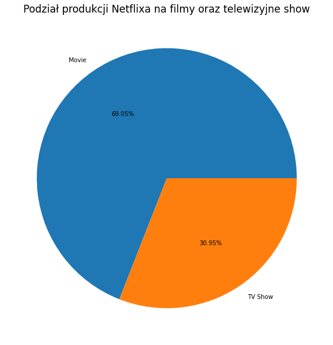

```python
wykres = plt.subplots(figsize = (10,10))
plt.pie(x=netflixData["type"].value_counts(),labels=netflixData["type"].value_counts().index , autopct= "%.2f%%" )
plt.title('Podział produkcji Netflixa na filmy oraz telewizyjne show', size=17)
```

Jak wynika z powyższego wykresu, zdecydowaną wiekszość produkcji stanowią filmy, a zaledwie co trzecia to show telewizyjne.

### W jaki sposób klasyfikowane są produkcje zapisane w zbiorze danych?

Czy wszystkie produkcje Netflixa są to programy i filmy wyłacznie dla dzieci i młodzieży? A moze jest wręcz przeciwnie - czas spędzany przez nich na oglądaniu jest czasem, podczas którego mają one styczność z elementami, na które nie powinny patrzeć? Odpowiedzi na to pytanie udzieli diagram słupkowy, który zaprezentuje, jak klasyfikowane są "produkty" czołowej firmy pod względem streamingu internetowego.

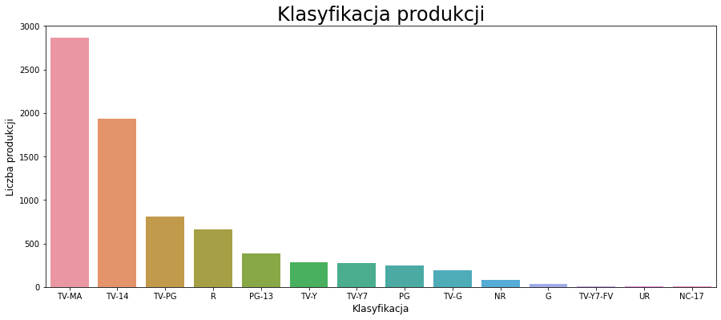

```python
plt.figure(figsize=(15,6))
temp= netflixData.rating.value_counts()
sns.barplot(x="index" , y="rating" , data = temp.reset_index())
plt.xlabel("Klasyfikacja", size=12)
plt.ylabel("Liczba produkcji", size=12)
plt.title("Klasyfikacja produkcji", size=24)
```

Analiza powyższego wykresu nie pozostawia złudzeń - zdecydowana większość filmów i produkcji kierowana jest głównie do osób dorosłych lub powyżej 14 lat. Ze względu na fakt, że w Polsce obowiązują inne klasyfikacje, poniżej przytoczono opis klasyfikacji `TV-MA` oraz `TV-14`:

- TV-14: Ten program zawiera materiały, które wielu rodziców może uznać za nieodpowiednie dla dzieci poniżej 14 roku życia. Zachęca się rodziców do zwiększonego nadzoru dzieci oglądających program i przestrzega się przed pozostawieniem dzieci w wieku poniżej 14 lat bez opieki. Program ten może zawierać sugestywny dialog (D), mocny język (L), intensywne sytuacje seksualne (S) lub intensywną przemoc (V).
- TV-MA: Ten program został specjalnie przygotowany do oglądania przez dorosłych i dlatego może być nieodpowiedni dla dzieci poniżej 17 roku życia. Ten program może zawierać prymitywny nieprzyzwoity język (L), jawną aktywność seksualną (S) lub brutalną przemoc (V). Pamiętajmy o tym posiadając pociechy w rodzinie lub wśród znajomych. Aby jeszcze raz zaznaczyć, że to nie są żarty, poniżej przedstawiono jeszcze raz wykres klasyfikacji, zawężony do dwóch pierwszych pozycji.

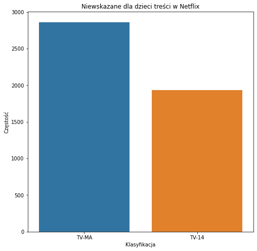

```python
wykres = plt.subplots(figsize = (8,8))
sns.barplot(x = netflixData['rating'].value_counts().index[0:2], y = netflixData['rating'].value_counts()[0:2])
plt.xlabel('Klasyfikacja')
plt.ylabel('Częstość')
plt.title('Niewskazane dla dzieci treści w Netflix')
```

### Ile premier rocznie ma miejsce na platformie Netflix?

Odejdźmy od tych niezbyt radosnych kwestii i zastanówmy się, czy tak wielka (i wciąż umacniająca swoją pozycję na rynku) firma jak Netflix, rokrocznie ma związek z coraz to większą liczbą produkcji? Czy może jednak stawia na jakość i ta liczba z roku na rok nie jest już coraz większa? Odpowiedzi dostarczy nam diagram słupkowy prezentujący liczbę premier w kolejnych latach

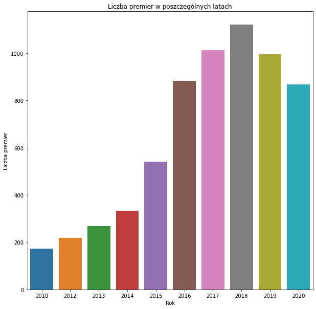

```python
ax = plt.subplots(figsize = (10,10))
sns.barplot(x = netflixData['release_year'].value_counts().index[:10], y = netflixData['release_year'].value_counts()[:10])
plt.xlabel('Rok')
plt.ylabel('Liczba premier')
plt.title('Liczba premier w poszczególnych latach')
```

Przygotowany wykres bardzo obrazowo prezentuje różne fazy w historii rozwoju firmy Netflix. Widać na nim, jak firma zwiększała swój udział (wiąże się to niewątpliwie również z budżetem) i z roku na rok tworzyła coraz więcej różnego rodzaju produkcji. Niemniej jednak po osiągnięciu szczytowego punktu w roku 2018 (ok 1100 filmów i show telewizyjnych) minimalnie zmniejszyła liczbę produkcji w kolejnych latach. Może to mieć związek ze stawianiem przez przedsiębiorstwo na jakość.

### Jakie są preferencje użytkowników? Co wolą oglądać? Co Netflix kręci?

Analizowany zbiór danych może również dostarczyć odpowiedzi na inne pytania - np. Jakie są preferencje użytkowników jeśli chodzi o oglądanie różnego typu produkcji w określonych latach? Wskutek czego jakiego typu produkcji powstaje więcej? Odpowiedź na to pytanie znajduje się w poniższej tabeli pomocniczej oraz na wykresie punktowym:

```python
movieData = netflixData[netflixData['type'] == 'Movie']
showData = netflixData[netflixData['type'] == 'TV Show']
tempTypeData = netflixData[['type', 'release_year']]
tempTypeData = tempTypeData.value_counts().to_frame()
tempTypeData.reset_index(level=[0,1],inplace=True)
tempTypeData=tempTypeData.rename(columns={0:'count'})
tempTypeData = pd.concat([tempTypeData[tempTypeData['type'] == 'Movie'][:10], tempTypeData[tempTypeData['type']== 'TV Show'][:10]])
tempTypeData
```

|  | type | release_year | count |
| --- | --- | --- | --- |
| 0 | Movie | 2017 | 744 |
| 1 | Movie | 2018 | 734 |
| 2 | Movie | 2016 | 642 |
| 3 | Movie | 2019 | 582 |
| 6 | Movie | 2020 | 411 |
| 8 | Movie | 2015 | 382 |
| 10 | Movie | 2014 | 244 |
| 12 | Movie | 2013 | 202 |
| 14 | Movie | 2012 | 158 |
| 15 | Movie | 2010 | 136 |
| 4 | TV Show | 2020 | 457 |
| 5 | TV Show | 2019 | 414 |
| 7 | TV Show | 2018 | 387 |
| 9 | TV Show | 2017 | 268 |
| 11 | TV Show | 2016 | 240 |
| 13 | TV Show | 2015 | 159 |
| 19 | TV Show | 2014 | 90 |
| 22 | TV Show | 2013 | 65 |
| 24 | TV Show | 2012 | 61 |
| 28 | TV Show | 2011 | 39 |

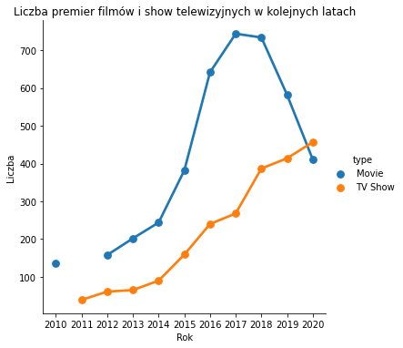

```python
sns.catplot(x = 'release_year', y = 'count', hue = 'type', data = tempTypeData, kind = 'point')
plt.rcParams['figure.figsize']=(20,20)
plt.xlabel('Rok')
plt.ylabel('Liczba')
plt.title('Liczba premier filmów i show telewizyjnych w kolejnych latach', size=12)
```

### Jakie słowa najczęściej występują w opisach filmów?

Powszechne jest twierdzenie, że dzisiejszą telewizję i internet zdominowały negatywne aspekty - przemoc, przestępstwa, narkotyki czy seks w najgorszych możliwych okolicznościach. Korzystając z bardzo ciekawej biblioteki WordCloud jestesmy w stanie przekonać się, czy tak faktycznie jest, wyciągając wnioski ze słów, które pojawiają się w opisach filmów.

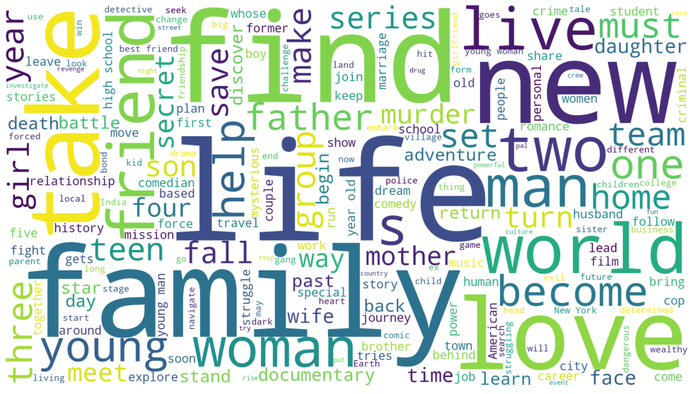

```python
plt.figure(figsize=(20,10))
wordcloud = WordCloud(background_color='white',
                      width=1920,
                      height=1080
                      ).generate(" ".join(netflixData.description))
plt.imshow(wordcloud)
plt.axis('off')
plt.show()
```

Wnioskując po wygenerowanym obrazie jednak można odetchnąć z ulgą - jest dla nas jako społeczeństwa nadzieja :) Najczęstsze pojawiające się słowa to życie, rodzina, miłość, co w przypadku filmów z happy endem dobrze rokuje.

### Jacy reżyserzy najczęściej tworzą dla Netflix?

Na zakończenie jeszcze jedna szybka analiza - w prostej tabeli przedstawieni zostaną najczęściej pojawiający sie reżyserzy.

```python
directorData = netflixData.groupby(["country", "rating", "director"]).agg({ "title":"count"}).reset_index()
directorData = pd.DataFrame(directorData[directorData["director"] != "Unknown"].groupby("director")["title"].sum().sort_values(ascending=False)).reset_index().head(15)
directorData = directorData.rename({"title":"Liczba tytulow"}, axis=1)
directorData.style.hide_index()
```

| director | Liczba tytulow |
| --- | --- |
| Raúl Campos, Jan Suter | 18 |
| Marcus Raboy | 15 |
| Jay Karas | 14 |
| Cathy Garcia-Molina | 13 |
| Youssef Chahine | 12 |
| Jay Chapman | 12 |
| Martin Scorsese | 12 |
| Steven Spielberg | 10 |
| David Dhawan | 9 |
| Johnnie To | 8 |
| Robert Rodriguez | 8 |
| Shannon Hartman | 8 |
| Ryan Polito | 8 |
| Hakan Algül | 8 |
| Don Michael Paul | 7 |

Jak widać, najpopularniejszą parą reżyserów są Raul Campos oraz Jan Suter. Co ciekawe, bardzo popularne nazwiska, takie jak Martin Scorsese, Steven Spielberg czy Robert Rodriguez również są związane z działalnością Netflix.

## Podsumowanie

Na powyższych przykładach zaprezentowano możliwości różnorodnego podejścia do analizy danych i różnych technik graficznego ich prezentowania. W ramach projektu pobrano mniej znany niż chociażby Titanic zbiór danych, zapoznano się z danymi i na różnego rodzaju wykresach zaprezentowano niektóre wnioski, które można na ich podstawie wyciągnąć. Starano się również komentować i objaśniać uzyskane rezultaty oraz odnosić je do rzeczywistych sytuacji. Dane zebrane w źródle danych mogą służyć do obrazowania m.in. rozwoju firmy czy zmiany upodobań odbiorców.